# NB3C_Character_Roles_Training

## Character role classifier

actor-category × role (joint)

**Revised methodology (Gehring-style character–role combinations).** Earlier versions predicted a role (villain / hero / victim) at the *snippet* level. That design could not say *which* actor held the role, and it could not be validated, because in the hand-coded data a role is always attached to a specific actor. This notebook now predicts **(actor category, role) combinations**, mirroring the hand coding and following Gehring's logic of coding character–role pairs (e.g. *Government–Villain*, *Corporations–Hero*).

### Unit of analysis

- NLI is run at the **actor-category level** — the 12 codebook categories (4 Chinese + 5 Indonesian + 3 International). The catch-all `*Others` is excluded.
- Each training/inference instance is a triple `(snippet, actor_category, role)`; the hypothesis is a short actor-anchored statement and the model predicts entailment.

### Data

- **Training**: `Batch3_Mar_26/Indonesian Nickel Conflicts_raw dataset_all_3_batches.xlsx` (sheet `Quotation`). 242 snippets carry a character role; **197** also carry a codebook actor and are used here. The 45 role-only snippets are dropped — their role cannot be attached to an actor.
- **Inference**: `conflict_snippets_df_2705_NER.xlsx` (NER output from NB3B). Only snippets containing a recognized codebook actor are scored; each detected category is scored against the three roles.

### Pairing rule (training)

For each kept snippet, positives are the cross-product of its coded actor categories × its coded roles; negatives are those same coded actors paired with the roles *not* coded for the snippet (within-coded-actors only — an absent category is never treated as a negative).

### Outputs

- `character_roles_actor_predictions.csv` — long format `(snippet, actor_category, role, prob, pred)` — **primary**.
- `character_roles_predictions.csv` — snippet-level roll-up (max over actors) kept for the legacy descriptive figures below.

```python
import pandas as pd
import re
import json

# ── 12 codebook actor categories (NLI is performed at this level; *Others excluded) ──
with open('ner_actor_codebook.json', encoding='utf-8') as f:
    _cb = json.load(f)
ACTOR_CATEGORIES  = [r['actor_label'] for r in _cb if not r['actor_label'].startswith('*')]
ACTOR_DEFINITIONS = {r['actor_label']: r['definition'] for r in _cb}
assert len(ACTOR_CATEGORIES) == 12, ACTOR_CATEGORIES

ROLE_COLS = ['villain', 'hero', 'victim']

# ── Map hand-coder category labels → codebook actor_label ─────────────────────
HANDCODE_TO_CODEBOOK = {
    'Local community & workers 3A'                                  : 'Indonesian local community & workers',
    'Chinese firms/SOEs 2A'                                         : 'Chinese firms/SOEs',
    'Government 1A: central government/presindent'                  : 'Indonesian government: central government/president',
    'Chinese worker 2D'                                             : 'Chinese worker',
    'Chinese government 2C'                                         : 'Chinese government',
    'Government 1B: local government (provincial/regional officials)': 'Indonesian government: local government (provincial/regional officials)',
    'International companies & foreign investments 4B'              : 'International companies',
    'International government 4C'                                   : 'International governmental and intergovernmental actors',
    'Chinese DFIs (banks) 2B'                                       : 'Chinese DFIs (banks)',
    'International actors 4A (international NGOs/watchdogs/media)'   : 'International NGOs/watchdog',
}

# ── Load hand-coded batch data ────────────────────────────────────────────────
BATCH_PATH = r'../ln_labeling/Batch3_Mar_26/Indonesian Nickel Conflicts_raw dataset_all_3_batches.xlsx'
raw = pd.read_excel(BATCH_PATH, sheet_name='Quotation')
print(f'Raw coded rows: {len(raw)}')

def parse_codes(codes_str):
    """Return (set of codebook actor categories, set of base roles) for one snippet."""
    s = str(codes_str) if not pd.isna(codes_str) else ''
    segments = re.split(r',\s*(?=Actor categories:|Character Role:|Conflict types:|Overall tone:)', s)
    actors, roles = set(), set()
    for seg in segments:
        seg = seg.strip()
        low = seg.lower()
        if low.startswith('actor categories:'):
            val = seg.split(':', 1)[1].strip()
            mapped = HANDCODE_TO_CODEBOOK.get(val)
            if mapped:
                actors.add(mapped)
        elif low.startswith('character role:'):
            tail = low.split(':', 1)[1]          # may contain sub-tags, e.g. "villain – chinese firms"
            for r in ROLE_COLS:
                if r in tail:
                    roles.add(r)
    return actors, roles

raw['snippet'] = raw['Text Content'].fillna('').astype(str).str.strip()
_parsed = raw['Codes'].apply(parse_codes)
raw['hc_actors'] = _parsed.apply(lambda x: x[0])
raw['hc_roles']  = _parsed.apply(lambda x: x[1])

n_role        = (raw['hc_roles'].apply(len) > 0).sum()
n_role_actor  = ((raw['hc_roles'].apply(len) > 0) & (raw['hc_actors'].apply(len) > 0)).sum()

# Keep snippets with a usable text, ≥1 role AND ≥1 mapped codebook actor.
mask = (raw['snippet'].str.len() > 10) & (raw['hc_roles'].apply(len) > 0) & (raw['hc_actors'].apply(len) > 0)
train_df = raw.loc[mask, ['snippet', 'Codes', 'hc_actors', 'hc_roles']].reset_index(drop=True)

print(f'Snippets with a character role            : {n_role}')
print(f'  ... also carrying a codebook actor (kept): {n_role_actor}')
print(f'  ... after blank-text filter (train_df)   : {len(train_df)}')
print('\nHand-coded role frequency (snippet level):')
for r in ROLE_COLS:
    print(f'  {r:<8} {train_df["hc_roles"].apply(lambda s: r in s).sum()}')
print('\nHand-coded actor frequency (snippet level):')
_ac = pd.Series([a for s in train_df['hc_actors'] for a in s]).value_counts()
print(_ac.to_string())
```

```
Raw coded rows: 593
Snippets with a character role            : 242
  ... also carrying a codebook actor (kept): 197
  ... after blank-text filter (train_df)   : 197

Hand-coded role frequency (snippet level):
  villain  78
  hero     44
  victim   76

Hand-coded actor frequency (snippet level):
Indonesian local community & workers                                       62
Chinese firms/SOEs                                                         49
Indonesian government: central government/president                        47
Chinese worker                                                             26
Chinese government                                                         12
Indonesian government: local government (provincial/regional officials)    11
International companies                                                     4
International governmental and intergovernmental actors                     2
Chinese DFIs (banks)                                                        2
International NGOs/watchdog                                                 1
```

```python
# ── Actor-anchored NLI hypothesis (Gehring-style character–role combination) ──
# Decision: short role phrase (actor + concise gloss), not the full codebook definition.
ROLE_GLOSS = {
    'villain': 'an actor causing harm, wrongdoing, or threat',
    'hero':    'an actor providing help, solutions, or positive change',
    'victim':  'an actor suffering harm, loss, or injustice',
}

def make_hypothesis(actor_category, role):
    return f'This text portrays {actor_category} as a {role} — {ROLE_GLOSS[role]}.'

print('Example hypotheses:')
for a in ['Chinese firms/SOEs', 'Indonesian local community & workers']:
    for r in ROLE_COLS:
        print('  ', make_hypothesis(a, r))
```

```
Example hypotheses:
   This text portrays Chinese firms/SOEs as a villain — an actor causing harm, wrongdoing, or threat.
   This text portrays Chinese firms/SOEs as a hero — an actor providing help, solutions, or positive change.
   This text portrays Chinese firms/SOEs as a victim — an actor suffering harm, loss, or injustice.
   This text portrays Indonesian local community & workers as a villain — an actor causing harm, wrongdoing, or threat.
   This text portrays Indonesian local community & workers as a hero — an actor providing help, solutions, or positive change.
   This text portrays Indonesian local community & workers as a victim — an actor suffering harm, loss, or injustice.
```

```python
import numpy as np

# ── Build (snippet, actor_category, role) training triples ───────────────────
# Positives = coded actors × coded roles (cross-product within the snippet).
# Negatives = coded actors × the roles NOT coded for that snippet
#             (within-coded-actors only; an absent category is never a negative).
nli_rows = []
for _, row in train_df.iterrows():
    for actor in sorted(row['hc_actors']):
        for role in ROLE_COLS:
            nli_rows.append({
                'snippet'       : row['snippet'],
                'actor_category': actor,
                'role'          : role,
                'hypothesis'    : make_hypothesis(actor, role),
                'label'         : int(role in row['hc_roles']),
            })
nli_df = pd.DataFrame(nli_rows)

# ── Snippet-level train/val split (no snippet appears in both → no leakage) ───
snips = nli_df['snippet'].drop_duplicates().tolist()
rng = np.random.RandomState(42)
rng.shuffle(snips)
n_val     = max(1, int(round(0.2 * len(snips))))
val_snips = set(snips[:n_val])
nli_val       = nli_df[nli_df['snippet'].isin(val_snips)].reset_index(drop=True)
nli_train_raw = nli_df[~nli_df['snippet'].isin(val_snips)].reset_index(drop=True)

print(f'Actor-role pairs total : {len(nli_df):,}  '
      f'(pos={nli_df["label"].sum()}, neg={(nli_df["label"]==0).sum()})')
print(f'  train snippets/pairs : {len(snips)-n_val} / {len(nli_train_raw):,}  '
      f'({nli_train_raw["label"].sum()} pos)')
print(f'  val   snippets/pairs : {n_val} / {len(nli_val):,}  ({nli_val["label"].sum()} pos)')
print('\nPositives per role:')
print(nli_df[nli_df['label'] == 1].groupby('role').size().to_string())
print('\nPositives per actor category:')
print(nli_df[nli_df['label'] == 1].groupby('actor_category').size().sort_values(ascending=False).to_string())
```

```
Actor-role pairs total : 648  (pos=218, neg=430)
  train snippets/pairs : 157 / 522  (176 pos)
  val   snippets/pairs : 39 / 126  (42 pos)

Positives per role:
role
hero       47
victim     87
villain    84

Positives per actor category:
actor_category
Indonesian local community & workers                                       63
Chinese firms/SOEs                                                         50
Indonesian government: central government/president                        47
Chinese worker                                                             26
Chinese government                                                         12
Indonesian government: local government (provincial/regional officials)    11
International companies                                                     4
Chinese DFIs (banks)                                                        2
International governmental and intergovernmental actors                     2
International NGOs/watchdog                                                 1
```

```python
from transformers import (
    AutoTokenizer, AutoModelForSequenceClassification,
    Trainer, TrainingArguments, EarlyStoppingCallback
)
from sklearn.metrics import f1_score, classification_report
import torch
import numpy as np
from torch.utils.data import Dataset

NLI_MODEL = 'cross-encoder/nli-roberta-base'
MAX_LEN   = 256
THRESHOLD = 0.6
MODEL_DIR = r'nli_character_actor_model'

tokenizer_nli = AutoTokenizer.from_pretrained(NLI_MODEL)

class NLIDataset(Dataset):
    def __init__(self, premises, hypotheses, labels=None):
        self.enc = tokenizer_nli(
            premises, hypotheses,
            truncation=True, padding=True, max_length=MAX_LEN
        )
        self.labels = labels
    def __len__(self): return len(self.enc['input_ids'])
    def __getitem__(self, idx):
        item = {k: torch.tensor(v[idx]) for k, v in self.enc.items()}
        if self.labels is not None:
            item['labels'] = torch.tensor(self.labels[idx], dtype=torch.long)
        return item

# Oversample positive pairs 2x (training split only)
pos_train = nli_train_raw[nli_train_raw['label'] == 1]
nli_train = pd.concat([nli_train_raw, pos_train]).sample(frac=1, random_state=42).reset_index(drop=True)
print(f'After oversampling — train: {len(nli_train)}  '
      f'(pos={nli_train["label"].sum()}, neg={(nli_train["label"]==0).sum()})  val: {len(nli_val)}')

train_ds = NLIDataset(nli_train['snippet'].tolist(),
                      nli_train['hypothesis'].tolist(),
                      nli_train['label'].tolist())
val_ds   = NLIDataset(nli_val['snippet'].tolist(),
                      nli_val['hypothesis'].tolist(),
                      nli_val['label'].tolist())

model_nli = AutoModelForSequenceClassification.from_pretrained(
    NLI_MODEL, num_labels=2, ignore_mismatched_sizes=True
)

n_neg = (nli_train['label'] == 0).sum()
n_pos = (nli_train['label'] == 1).sum()
class_weights = torch.tensor([1.0, n_neg / n_pos]).float()
print(f'Class weights: no-role={class_weights[0]:.2f}, role={class_weights[1]:.2f}')

class WeightedCETrainer(Trainer):
    def compute_loss(self, model, inputs, return_outputs=False, **kwargs):
        labels  = inputs.pop('labels')
        outputs = model(**inputs)
        loss = torch.nn.CrossEntropyLoss(
            weight=class_weights.to(outputs.logits.device)
        )(outputs.logits, labels)
        return (loss, outputs) if return_outputs else loss

def compute_metrics_nli(eval_pred):
    logits, labels = eval_pred
    probs  = torch.softmax(torch.tensor(logits), dim=-1)[:, 1].numpy()
    preds  = (probs >= THRESHOLD).astype(int)
    labels = labels.astype(int).flatten()
    return {
        'f1'       : f1_score(labels, preds, zero_division=0),
        'f1_macro' : f1_score(labels, preds, average='macro', zero_division=0),
    }

args_nli = TrainingArguments(
    output_dir                  = MODEL_DIR,
    num_train_epochs            = 10,
    per_device_train_batch_size = 16,
    per_device_eval_batch_size  = 32,
    eval_strategy               = 'epoch',
    save_strategy               = 'epoch',
    load_best_model_at_end      = True,
    metric_for_best_model       = 'f1_macro',
    greater_is_better           = True,
    learning_rate               = 2e-5,
    warmup_ratio                = 0.1,
    weight_decay                = 0.1,
    label_smoothing_factor      = 0.1,
    logging_steps               = 10,
    seed                        = 42,
    report_to                   = 'none',
)

trainer_nli = WeightedCETrainer(
    model           = model_nli,
    args            = args_nli,
    train_dataset   = train_ds,
    eval_dataset    = val_ds,
    compute_metrics = compute_metrics_nli,
    callbacks       = [EarlyStoppingCallback(early_stopping_patience=3)],
)

trainer_nli.train()

# Final evaluation on the held-out actor-role pairs
pred_out   = trainer_nli.predict(val_ds)
probs_val  = torch.softmax(torch.tensor(pred_out.predictions), dim=-1)[:, 1].numpy()
preds_val  = (probs_val >= THRESHOLD).astype(int)
labels_val = nli_val['label'].values.astype(int)
print(classification_report(labels_val, preds_val,
                            target_names=['no role', 'role present'], zero_division=0))

nli_val_res = nli_val.copy()
nli_val_res['pred'] = preds_val
nli_val_res['prob'] = probs_val.round(4)

print(f'\nPer-role F1 (threshold={THRESHOLD}):')
per_role_f1s = []
for role, grp in nli_val_res.groupby('role'):
    f1 = f1_score(grp['label'], grp['pred'], zero_division=0)
    per_role_f1s.append(f1)
    print(f'  {role:<8} F1={f1:.2f}  (n={len(grp)}, pos={grp["label"].sum()})')
print(f'  Macro over roles: {np.mean(per_role_f1s):.3f}')
```

```
After oversampling — train: 698  (pos=352, neg=346)  val: 126
```

```
Some weights of RobertaForSequenceClassification were not initialized from the model checkpoint at cross-encoder/nli-roberta-base and are newly initialized because the shapes did not match:
- classifier.out_proj.bias: found shape torch.Size([3]) in the checkpoint and torch.Size([2]) in the model instantiated
- classifier.out_proj.weight: found shape torch.Size([3, 768]) in the checkpoint and torch.Size([2, 768]) in the model instantiated
You should probably TRAIN this model on a down-stream task to be able to use it for predictions and inference.
```

```
Class weights: no-role=1.00, role=0.98
```

[308/440 01:09 < 00:29, 4.43 it/s, Epoch 7/10]

| Epoch | Training Loss | Validation Loss | F1 | F1 Macro |
| --- | --- | --- | --- | --- |
| 1 | 0.440100 | 0.444591 | 0.658537 | 0.746915 |
| 2 | 0.189800 | 0.190403 | 0.917647 | 0.937865 |
| 3 | 0.028000 | 0.230630 | 0.923077 | 0.944297 |
| 4 | 0.018700 | 0.196963 | 0.952381 | 0.964286 |
| 5 | 0.000700 | 0.227354 | 0.952381 | 0.964286 |
| 6 | 0.000400 | 0.233876 | 0.952381 | 0.964286 |
| 7 | 0.000300 | 0.248100 | 0.939759 | 0.955087 |

```
              precision    recall  f1-score   support

     no role       0.98      0.98      0.98        84
role present       0.95      0.95      0.95        42

    accuracy                           0.97       126
   macro avg       0.96      0.96      0.96       126
weighted avg       0.97      0.97      0.97       126


Per-role F1 (threshold=0.6):
  hero     F1=0.92  (n=42, pos=12)
  victim   F1=1.00  (n=42, pos=10)
  villain  F1=0.95  (n=42, pos=20)
  Macro over roles: 0.956
```

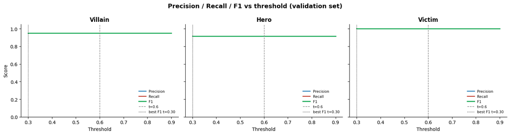

```
Saved: character_threshold_curves.png
```

```python
import matplotlib.pyplot as plt
from sklearn.metrics import precision_score, recall_score

# ── Threshold sweep: precision / recall / F1 per role ────────────────────────
thresholds = np.arange(0.3, 0.9, 0.02)

fig, axes = plt.subplots(1, 3, figsize=(15, 4), sharey=True)
colors = {'precision': '#2980B9', 'recall': '#C0392B', 'f1': '#27AE60'}

for ax, role in zip(axes, ROLE_COLS):
    grp = nli_val_res[nli_val_res['role'] == role]
    y_true = grp['label'].values
    y_prob  = grp['prob'].values

    precs, recs, f1s = [], [], []
    for t in thresholds:
        preds = (y_prob >= t).astype(int)
        precs.append(precision_score(y_true, preds, zero_division=0))
        recs.append(recall_score(y_true, preds, zero_division=0))
        f1s.append(f1_score(y_true, preds, zero_division=0))

    best_t = thresholds[np.argmax(f1s)]
    ax.plot(thresholds, precs, label='Precision', color=colors['precision'], lw=1.8)
    ax.plot(thresholds, recs,  label='Recall',    color=colors['recall'],    lw=1.8)
    ax.plot(thresholds, f1s,   label='F1',        color=colors['f1'],        lw=2.2)
    ax.axvline(0.6,    color='gray',  lw=1, linestyle='--', label='t=0.6')
    ax.axvline(best_t, color='black', lw=1, linestyle=':',  label=f'best F1 t={best_t:.2f}')
    ax.set_title(role.capitalize(), fontsize=12, fontweight='bold')
    ax.set_xlabel('Threshold')
    ax.set_ylim(0, 1.05)
    ax.spines[['top', 'right']].set_visible(False)
    ax.legend(fontsize=7.5, frameon=False)

axes[0].set_ylabel('Score')
fig.suptitle('Precision / Recall / F1 vs threshold (validation set)', fontsize=13, fontweight='bold')
plt.tight_layout()
plt.savefig('character_threshold_curves.png', dpi=150, bbox_inches='tight')
plt.show()
print('Saved: character_threshold_curves.png')
```

```python
# ── Inference: score every (snippet, detected actor category, role) ──────────
import json

device = torch.device('cuda' if torch.cuda.is_available() else 'cpu')
print(f'Running on: {device}')
model_nli.eval().to(device)

# Recognized-actor detection (reuse NB3B codebook named-entity matching) -------
with open('ner_actor_codebook.json', encoding='utf-8') as f:
    _cb_inf = json.load(f)
CONTEXT_ONLY = {'market', 'environment'}

def _expand_terms(terms):
    out = []
    for raw in terms:
        for seg in str(raw).split(';'):
            for alt in seg.split(' OR '):
                alt = alt.strip()
                if alt:
                    out.append(alt)
    return out

# Only the 12 substantive categories (drop *Others).
_ner = [{'actor_label': r['actor_label'], 'ents': _expand_terms(r['named_entities'])}
        for r in _cb_inf if not r['actor_label'].startswith('*')]

def _make_pattern(term):
    t = term.lower()
    if t.endswith('y') and len(t) > 2 and t[-2] not in 'aeiou':
        return r'\b' + re.escape(t[:-1]) + r'(?:y|ies)\b'
    if re.search(r'(?:s|x|ch|sh|z)$', t):
        return r'\b' + re.escape(t) + r'(?:es)?\b'
    return r'\b' + re.escape(t) + r's?\b'

# Pre-compile one combined regex per category for speed.
_cat_patterns = {}
for rec in _ner:
    pats = [_make_pattern(e) for e in rec['ents'] if e.lower() not in CONTEXT_ONLY]
    if pats:
        _cat_patterns[rec['actor_label']] = re.compile('|'.join(pats))

def detect_categories(text):
    tl = str(text).lower()
    return [label for label, pat in _cat_patterns.items() if pat.search(tl)]

def clean_snippet(text):
    if pd.isna(text): return ''
    text = re.sub(r'\s+', ' ', str(text)).strip()
    text = re.sub(r'\b\d{6,}\b', '', text)
    return text

INF_PATH = r'conflict_snippets_df_2705_NER.xlsx'
snippets_df = pd.read_excel(INF_PATH)
snippets_df['snippet_clean']      = snippets_df['snippet'].apply(clean_snippet)
snippets_df['present_categories'] = snippets_df['snippet_clean'].apply(detect_categories)
snippets_df = snippets_df.reset_index(drop=True)
snippets_df['snippet_id'] = snippets_df.index

has_actor = snippets_df['present_categories'].apply(len) > 0
print(f'Total snippets               : {len(snippets_df):,}')
print(f'With >=1 recognized actor    : {has_actor.sum():,}  (scored)')
print(f'Without a recognized actor   : {(~has_actor).sum():,}  (not scored)')

# Build inference instances: (snippet_id, category, role) ----------------------
inst = []
for sid, cats in snippets_df.loc[has_actor, 'present_categories'].items():
    for cat in cats:
        for role in ROLE_COLS:
            inst.append((sid, cat, role))
inst_df = pd.DataFrame(inst, columns=['snippet_id', 'actor_category', 'role'])
inst_df['hypothesis'] = [make_hypothesis(a, r) for a, r in zip(inst_df['actor_category'], inst_df['role'])]
inst_df['snippet']    = inst_df['snippet_id'].map(snippets_df['snippet_clean'])
print(f'Actor-role instances to score: {len(inst_df):,}')

# Batched NLI scoring ----------------------------------------------------------
BATCH = 128
probs = []
prem  = inst_df['snippet'].tolist()
hyp   = inst_df['hypothesis'].tolist()
for i in range(0, len(prem), BATCH):
    enc = tokenizer_nli(
        prem[i:i + BATCH], hyp[i:i + BATCH],
        truncation=True, padding=True, max_length=256, return_tensors='pt'
    ).to(device)
    with torch.no_grad():
        logits = model_nli(**enc).logits
    probs.extend(torch.softmax(logits, dim=-1)[:, 1].cpu().numpy().tolist())

inst_df['prob'] = np.round(probs, 3)
inst_df['pred'] = (inst_df['prob'] >= THRESHOLD).astype(int)

print(f'\nPredicted positive (actor, role) combinations: {int(inst_df["pred"].sum()):,}')
print('\nPositive combinations per role:')
print(inst_df[inst_df['pred'] == 1].groupby('role').size().to_string())
```

```
Running on: cuda
Total snippets               : 2,705
With >=1 recognized actor    : 1,381  (scored)
Without a recognized actor   : 1,324  (not scored)
Actor-role instances to score: 5,568

Predicted positive (actor, role) combinations: 1,901

Positive combinations per role:
role
hero        496
victim      191
villain    1214
```

```python
# ── Save long-format actor-role predictions + snippet-level roll-up ──────────
meta_cols = [c for c in ['snippet_id', 'article_id', 'title', 'outlet', 'date', 'year_month']
             if c in snippets_df.columns]

long_df = inst_df.merge(
    snippets_df[meta_cols + ['snippet']].rename(columns={'snippet': 'snippet_text'}),
    on='snippet_id', how='left'
)
LONG_OUT = r'character_roles_actor_predictions.csv'
long_df.to_csv(LONG_OUT, index=False)
print(f'Saved {len(long_df):,} actor-role rows → {LONG_OUT}')
print(f'  columns: {list(long_df.columns)}')

# Snippet-level roll-up (max over actors) — kept for the legacy figures below ---
roll = snippets_df.copy()
for role in ROLE_COLS:
    pr = inst_df[inst_df['role'] == role].groupby('snippet_id')['prob'].max()
    roll[f'prob__{role}'] = roll['snippet_id'].map(pr).fillna(0.0).round(3)
    roll[f'pred__{role}'] = (roll[f'prob__{role}'] >= THRESHOLD).astype(int)
roll['n_roles_predicted'] = roll[[f'pred__{r}' for r in ROLE_COLS]].sum(axis=1)

ROLL_OUT = r'character_roles_predictions.csv'
roll.drop(columns=['snippet_clean'], errors='ignore').to_csv(ROLL_OUT, index=False)
snippets_nli = roll                      # alias used by the legacy descriptive cells
print(f'Saved snippet-level roll-up    → {ROLL_OUT}')
print(f'  snippets with >=1 role: {(roll["n_roles_predicted"] > 0).sum():,}')
```

```
Saved 5,568 actor-role rows → character_roles_actor_predictions.csv
  columns: ['snippet_id', 'actor_category', 'role', 'hypothesis', 'snippet', 'prob', 'pred', 'article_id', 'title', 'outlet', 'date', 'year_month', 'snippet_text']
Saved snippet-level roll-up    → character_roles_predictions.csv
  snippets with >=1 role: 1,330
```

```python
# ── Validation at the ACTOR-ROLE level (held-out snippets) ───────────────────
# Because predictions are now (actor, role) pairs, they can be checked directly
# against the hand-coded actor-role pairs,  which was impossible under the old
# snippet-level scheme.
from sklearn.metrics import precision_recall_fscore_support

val_eval = nli_val_res.copy()
print('Validation = actor-role pairs from held-out snippets\n')

p, r, f, _ = precision_recall_fscore_support(
    val_eval['label'], val_eval['pred'], average='binary', zero_division=0)
print(f'Overall (role present):  P={p:.2f}  R={r:.2f}  F1={f:.2f}  '
      f'(pairs={len(val_eval)}, pos={int(val_eval["label"].sum())})')

print('\nPer-role:')
for role, grp in val_eval.groupby('role'):
    p, r, f, _ = precision_recall_fscore_support(
        grp['label'], grp['pred'], average='binary', zero_division=0)
    print(f'  {role:<8} P={p:.2f} R={r:.2f} F1={f:.2f} (n={len(grp)}, pos={int(grp["label"].sum())})')

print('\nPer actor category (only where validation positives exist):')
for cat, grp in val_eval.groupby('actor_category'):
    if grp['label'].sum() == 0:
        continue
    p, r, f, _ = precision_recall_fscore_support(
        grp['label'], grp['pred'], average='binary', zero_division=0)
    print(f'  {cat:<55} P={p:.2f} R={r:.2f} F1={f:.2f} (pos={int(grp["label"].sum())})')

# Inspect a few held-out errors to sanity-check the actor-role coupling.
err = val_eval[val_eval['label'] != val_eval['pred']]
print(f'\nHeld-out errors: {len(err)} / {len(val_eval)}')
for _, e in err.head(8).iterrows():
    kind = 'FN' if e['label'] == 1 else 'FP'
    print(f'  [{kind}] {e["actor_category"]} / {e["role"]} (p={e["prob"]:.2f}): {e["snippet"][:90]}')
```

```
Validation = actor-role pairs from held-out snippets

Overall (role present):  P=0.95  R=0.95  F1=0.95  (pairs=126, pos=42)

Per-role:
  hero     P=0.92 R=0.92 F1=0.92 (n=42, pos=12)
  victim   P=1.00 R=1.00 F1=1.00 (n=42, pos=10)
  villain  P=0.95 R=0.95 F1=0.95 (n=42, pos=20)

Per actor category (only where validation positives exist):
  Chinese DFIs (banks)                                    P=1.00 R=1.00 F1=1.00 (pos=1)
  Chinese firms/SOEs                                      P=0.94 R=0.94 F1=0.94 (pos=18)
  Chinese government                                      P=0.75 R=0.75 F1=0.75 (pos=4)
  Chinese worker                                          P=1.00 R=1.00 F1=1.00 (pos=2)
  Indonesian government: central government/president     P=1.00 R=1.00 F1=1.00 (pos=8)
  Indonesian government: local government (provincial/regional officials) P=1.00 R=1.00 F1=1.00 (pos=1)
  Indonesian local community & workers                    P=1.00 R=1.00 F1=1.00 (pos=8)

Held-out errors: 4 / 126
  [FN] Chinese firms/SOEs / villain (p=0.01): It is often Chinese investment, which makes the headlines .
  [FP] Chinese firms/SOEs / hero (p=1.00): It is often Chinese investment, which makes the headlines .
  [FP] Chinese government / villain (p=1.00): Those efforts come in competition with China's Green Belt and Road Initiative, which has f
  [FN] Chinese government / hero (p=0.00): Those efforts come in competition with China's Green Belt and Road Initiative, which has f
```

```python
# -- Actor x role association -- DIRECTLY from the joint model -----------------
# Three panels (Indonesia / China / International). Bars are coloured by the
# actor's geography (same palette as the actor-category figures in NB3B); the
# role (villain / hero / victim) is encoded by hatching, not colour.
import textwrap
import matplotlib.pyplot as plt
from matplotlib.patches import Patch

if 'inst_df' in globals():
    pos = inst_df[inst_df['pred'] == 1].copy()
else:
    _l = pd.read_csv('character_roles_actor_predictions.csv')
    pos = _l[_l['pred'] == 1].copy()

ct = (pos.pivot_table(index='actor_category', columns='role',
                      values='pred', aggfunc='sum', fill_value=0)
        .reindex(columns=ROLE_COLS, fill_value=0))
print('Predicted (actor category x role) positive counts:')
print(ct.to_string())

# Share of each role within an actor category (row-normalised).
share = ct.div(ct.sum(axis=1).replace(0, np.nan), axis=0) * 100

# Geography palette - identical to GROUP_COLORS used in NB3B.
GEO_COLORS = {'Indonesian': '#27AE60', 'Chinese': '#C0392B', 'International': '#2980B9'}
# Roles are distinguished by hatch only (colour now encodes geography).
role_hatch = {'villain': '...', 'hero': '///', 'victim': 'xxx'}


def _geo(cat):
    if cat.startswith('Indonesian'):
        return 'Indonesian'
    if cat.startswith('Chinese'):
        return 'Chinese'
    return 'International'


def _wrap(s, width=22):
    return textwrap.fill(str(s), width)


panels = ['Indonesian', 'Chinese', 'International']
panel_titles = {'Indonesian': 'Indonesia', 'Chinese': 'China', 'International': 'International'}

fig, axes = plt.subplots(1, 3, figsize=(18, 6))
for ax, geo in zip(axes, panels):
    cats = [c for c in ct.index if _geo(c) == geo]
    # order within panel by total positive mentions (most-mentioned on top)
    cats = ct.loc[cats].sum(axis=1).sort_values(ascending=False).index.tolist()
    color = GEO_COLORS[geo]
    left = np.zeros(len(cats))
    for role in ROLE_COLS:
        vals = np.nan_to_num(share.reindex(cats)[role].values)
        ax.barh(range(len(cats)), vals, left=left, color=color,
                hatch=role_hatch[role], edgecolor='white', linewidth=0.6)
        left += vals
    ax.set_yticks(range(len(cats)))
    ax.set_yticklabels([_wrap(c) for c in cats], fontsize=9)
    ax.invert_yaxis()
    ax.set_xlim(0, 100)
    ax.set_xlabel('Share of predicted role mentions (%)', fontsize=10)
    ax.set_title(panel_titles[geo], fontsize=13, fontweight='bold', color=color)
    ax.spines[['top', 'right']].set_visible(False)

# Shared role legend - hatch only, on a neutral swatch.
legend_handles = [Patch(facecolor='#888888', hatch=role_hatch[r], edgecolor='white',
                        label=r.capitalize()) for r in ROLE_COLS]
fig.legend(handles=legend_handles, frameon=False, ncol=3,
           loc='lower center', bbox_to_anchor=(0.5, -0.02), fontsize=11,
           title='Role (hatch)')
fig.suptitle('Character roles by actor category and geography - joint model',
             fontsize=15, fontweight='bold', y=1.02)
plt.tight_layout()
plt.savefig('actor_category_role_shares.png', dpi=150, bbox_inches='tight', facecolor='white')
plt.show()
print('\nSaved: actor_category_role_shares.png')

# Make the long-format predictions and a snippet-level frame available to the
# legacy descriptive cells that follow.
pred_df = snippets_nli[snippets_nli[[f'pred__{r}' for r in ROLE_COLS]].sum(axis=1) > 0].copy()
pred_df['date_parsed'] = pd.to_datetime(pred_df['date'], errors='coerce')
```

[output not shown]

### Legacy snippet-level descriptive figures

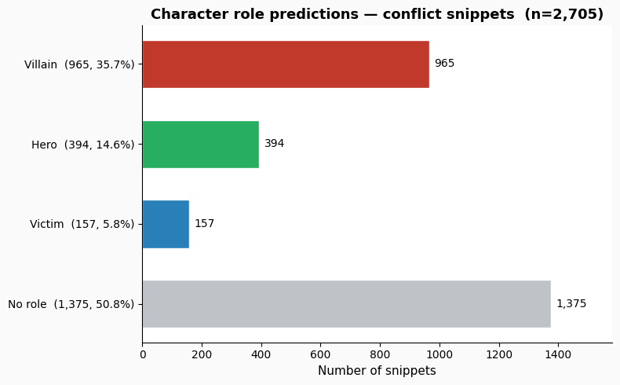

```
Role co-occurrence counts:
  villain + hero: 116
  villain + victim: 69
  hero + victim: 3
  all three: 2
```

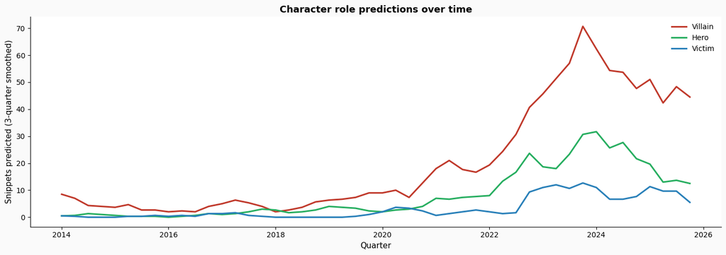

```
Saved: character_role_distribution.png + character_roles_over_time.png
```

```python
import matplotlib.pyplot as plt
import matplotlib.dates as mdates
from itertools import combinations

ROLE_COLORS = {'villain': '#C0392B', 'hero': '#27AE60', 'victim': '#2980B9'}
ROLE_LABELS = {'villain': 'Villain', 'hero': 'Hero', 'victim': 'Victim'}

total = len(snippets_nli)
counts = {r: int(snippets_nli[f'pred__{r}'].sum()) for r in ROLE_COLS}
none_n = int((snippets_nli['n_roles_predicted'] == 0).sum())

# ── Figure 1: role distribution bar chart ────────────────────────────────────
fig, ax = plt.subplots(figsize=(8, 5))
vals   = [counts[r] for r in ROLE_COLS] + [none_n]
colors = [ROLE_COLORS[r] for r in ROLE_COLS] + ['#BDC3C7']
labels = [f'{ROLE_LABELS[r]}  ({counts[r]:,}, {100*counts[r]/total:.1f}%)' for r in ROLE_COLS] + \
         [f'No role  ({none_n:,}, {100*none_n/total:.1f}%)']

bars = ax.barh(labels[::-1], vals[::-1], color=colors[::-1], edgecolor='white', height=0.6)
ax.bar_label(bars, fmt='{:,.0f}', padding=5, fontsize=10)
ax.set_xlabel('Number of snippets', fontsize=11)
ax.set_title(f'Character role predictions — conflict snippets  (n={total:,})',
             fontsize=13, fontweight='bold')
ax.spines[['top', 'right']].set_visible(False)
ax.set_xlim(0, max(vals) * 1.15)
fig.patch.set_facecolor('#fafafa')
plt.tight_layout()
plt.savefig('character_role_distribution.png', dpi=150, bbox_inches='tight', facecolor='#fafafa')
plt.show()

# ── Role co-occurrence ────────────────────────────────────────────────────────
print('Role co-occurrence counts:')
for r1, r2 in combinations(ROLE_COLS, 2):
    n = int(((snippets_nli[f'pred__{r1}'] == 1) & (snippets_nli[f'pred__{r2}'] == 1)).sum())
    print(f'  {r1} + {r2}: {n}')
n_all3 = int(((snippets_nli[[f'pred__{r}' for r in ROLE_COLS]] == 1).all(axis=1)).sum())
print(f'  all three: {n_all3}')

# ── Figure 2: roles over time (smoothed line) ─────────────────────────────────
snippets_nli['date_parsed'] = pd.to_datetime(snippets_nli['date'], errors='coerce')
snippets_nli['quarter']     = snippets_nli['date_parsed'].dt.to_period('Q')

time_role = (snippets_nli.groupby('quarter')[[f'pred__{r}' for r in ROLE_COLS]]
               .sum()
               .rename(columns={f'pred__{r}': r for r in ROLE_COLS})
               .sort_index())
time_role.index = time_role.index.to_timestamp()
smoothed = time_role.rolling(window=3, min_periods=1, center=True).mean()

fig, ax = plt.subplots(figsize=(14, 5))
for role in ROLE_COLS:
    ax.plot(smoothed.index, smoothed[role],
            label=ROLE_LABELS[role], color=ROLE_COLORS[role], lw=2.2)
ax.set_xlabel('Quarter', fontsize=11)
ax.set_ylabel('Snippets predicted (3-quarter smoothed)', fontsize=11)
ax.set_title('Character role predictions over time', fontsize=13, fontweight='bold')
ax.legend(fontsize=10, frameon=False)
ax.spines[['top', 'right']].set_visible(False)
fig.patch.set_facecolor('#fafafa')
plt.tight_layout()
plt.savefig('character_roles_over_time.png', dpi=150, bbox_inches='tight', facecolor='#fafafa')
plt.show()

print('Saved: character_role_distribution.png + character_roles_over_time.png')
```

```python
import json
import re
import pandas as pd
import numpy as np
import matplotlib.pyplot as plt
import seaborn as sns
import textwrap
from matplotlib.patches import Patch

# Use the in-memory predictions if available; otherwise fall back to the saved CSV.
if 'snippets_nli' in globals():
    pred_df = snippets_nli.copy()
else:
    pred_df = pd.read_csv('character_roles_predictions.csv')

ROLE_COLS = ['villain', 'hero', 'victim']
role_pred_cols = [f'pred__{r}' for r in ROLE_COLS]

# Keep only snippets with at least one predicted role.
pred_df = pred_df[pred_df[role_pred_cols].sum(axis=1) > 0].copy()

with open('ner_actor_codebook.json', 'r', encoding='utf-8') as fh:
    codebook = json.load(fh)


def _expand_codebook_terms(terms):
    expanded = []
    for raw in terms:
        for segment in str(raw).split(';'):
            segment = segment.strip()
            if not segment:
                continue
            for alt in segment.split(' OR '):
                alt = alt.strip()
                if alt:
                    expanded.append(alt)
    return expanded


def _codebook_terms(actor_labels):
    terms, seen = [], set()
    for rec in codebook:
        if rec['actor_label'] in actor_labels:
            for t in _expand_codebook_terms(rec['named_entities']) + _expand_codebook_terms(rec['trigger_phrases']):
                tl = t.lower().strip()
                if tl and tl not in seen:
                    seen.add(tl)
                    terms.append(tl)
    return terms


actor_groups = {
    'Chinese DFIs (banks)': {'Chinese DFIs (banks)'},
    'Chinese firms/SOEs': {'Chinese firms/SOEs'},
    'Chinese government': {'Chinese government'},
    'Chinese worker': {'Chinese worker'},
    'Indonesian government': {
        'Indonesian government: central government/president',
        'Indonesian government: local government (provincial/regional officials)',
    },
    'Indonesian firms/elites': {'Indonesian firms and local elites'},
    'Indonesian civil society': {'Indonesian local civil society'},
    'Indonesian local community & workers': {'Indonesian local community & workers'},
    'International governmental and intergovernmental actors': {'International governmental and intergovernmental actors'},
    'International companies': {'International companies'},
    'International NGOs/watchdog': {'International NGOs/watchdog'},
}

# Compile regexes for each actor category.
actor_patterns = {}
for cat, labels in actor_groups.items():
    terms = _codebook_terms(labels)
    if not terms:
        continue
    pattern = re.compile('|'.join(r'\b' + re.escape(t) + r'\b' for t in terms), re.IGNORECASE)
    actor_patterns[cat] = pattern


def _contains_actor(text, pattern):
    return bool(pattern.search(str(text)))


rows = []
for role in ROLE_COLS:
    role_df = pred_df[pred_df[f'pred__{role}'] == 1].copy()
    if role_df.empty:
        continue
    total = len(role_df)
    for cat, pattern in actor_patterns.items():
        n = role_df['snippet'].apply(lambda t: _contains_actor(t, pattern)).sum()
        rows.append({
            'role': role,
            'actor_category': cat,
            'n_snippets': int(n),
            'share': n / total,
            'share_pct': 100 * n / total,
        })

summary = pd.DataFrame(rows)
print('Share of role-positive snippets mentioning each actor category:')
print(summary.pivot(index='actor_category', columns='role', values='share_pct').round(1).to_string())

# Publication-style figure 1: top actor categories within each role.
sns.set_theme(style='whitegrid')
# Colour encodes geography; hatch encodes role (consistent with the joint-model
# figure above). Geography palette matches GROUP_COLORS in NB3B.
GEO_COLORS = {'Indonesian': '#27AE60', 'Chinese': '#C0392B', 'International': '#2980B9'}
GROUP_GEO = {'Indonesia': '#27AE60', 'China': '#C0392B', 'International': '#2980B9'}
role_hatch = {'villain': '...', 'hero': '///', 'victim': 'xxx'}


def _geo(cat):
    if cat.startswith('Indonesian'):
        return 'Indonesian'
    if cat.startswith('Chinese'):
        return 'Chinese'
    return 'International'


def _wrap(s, width=22):
    return textwrap.fill(str(s), width)


role_legend = [Patch(facecolor='#888888', hatch=role_hatch[r], edgecolor='white',
                     label=r.capitalize()) for r in ROLE_COLS]
geo_legend = [Patch(facecolor=GEO_COLORS[g], edgecolor='white', label=lbl)
              for g, lbl in [('Indonesian', 'Indonesia'), ('Chinese', 'China'),
                             ('International', 'International')]]

fig, axes = plt.subplots(1, 3, figsize=(18, 5.4), sharey=False)
for ax, role in zip(axes, ROLE_COLS):
    sub = (summary[summary['role'] == role]
           .sort_values('share_pct', ascending=False)
           .head(5))
    if sub.empty:
        ax.text(0.5, 0.5, 'No matches', ha='center', va='center', fontsize=12)
        ax.set_title(role.capitalize(), fontsize=13, fontweight='bold')
        ax.set_axis_off()
        continue

    bar_colors = [GEO_COLORS[_geo(c)] for c in sub['actor_category']]
    ax.barh(range(len(sub)), sub['share_pct'], color=bar_colors,
            hatch=role_hatch[role], edgecolor='white', height=0.8)
    ax.set_yticks(range(len(sub)))
    ax.set_yticklabels([_wrap(c) for c in sub['actor_category']])
    ax.invert_yaxis()
    ax.set_title(f'{role.capitalize()} snippets', fontsize=13, fontweight='bold')
    ax.set_xlabel('Share of role-positive snippets', fontsize=11)
    ax.set_xlim(0, max(sub['share_pct'].max(), 1) * 1.12)
    ax.grid(axis='x', linestyle='--', alpha=0.35)
    ax.spines[['top', 'right', 'left']].set_visible(False)
    ax.tick_params(axis='both', labelsize=10)

    for i, val in enumerate(sub['share_pct']):
        ax.text(val + 0.5, i, f'{val:.1f}', va='center', ha='left', fontsize=9, color='#2c3e50')

axes[0].set_ylabel('Actor category', fontsize=11)
fig.legend(handles=geo_legend, frameon=False, ncol=3, loc='lower center',
           bbox_to_anchor=(0.5, -0.04), fontsize=11, title='Geography (colour)')
fig.suptitle('Top actor categories among role-positive snippets', fontsize=16, fontweight='bold', y=1.03)
plt.tight_layout()
plt.savefig('legacy_top_actor_categories_by_role.png', dpi=300, bbox_inches='tight', facecolor='white')
plt.show()
```

```python
# Publication-style figure 2: stacked vertical bars by broad actor group.
actor_group_map = {
    'International': {
        'International governmental and intergovernmental actors',
        'International companies',
        'International NGOs/watchdog',
    },
    'China': {
        'Chinese DFIs (banks)',
        'Chinese firms/SOEs',
        'Chinese government',
        'Chinese worker',
    },
    'Indonesia': {
        'Indonesian government: central government/president',
        'Indonesian government: local government (provincial/regional officials)',
        'Indonesian firms and local elites',
        'Indonesian local civil society',
        'Indonesian local community & workers',
    },
}

stack_rows = []
for group_name, labels in actor_group_map.items():
    terms = _codebook_terms(labels)
    if not terms:
        continue
    pattern = re.compile('|'.join(r'\b' + re.escape(t) + r'\b' for t in terms), re.IGNORECASE)
    group_mask = pred_df['snippet'].apply(lambda t: _contains_actor(t, pattern))
    group_df = pred_df[group_mask].copy()
    if group_df.empty:
        continue
    total = len(group_df)
    for role in ROLE_COLS:
        n = int(group_df[f'pred__{role}'].sum())
        stack_rows.append({
            'actor_group': group_name,
            'role': role,
            'share_pct': 100 * n / total,
        })

stack_summary = pd.DataFrame(stack_rows).pivot(index='actor_group', columns='role', values='share_pct').reindex(index=['International', 'China', 'Indonesia'])

fig, ax = plt.subplots(figsize=(8.5, 5.2))
bottom = np.zeros(len(stack_summary))
for role in ROLE_COLS:
    vals = stack_summary[role].astype(float).to_numpy()
    bars = ax.bar(stack_summary.index, vals, bottom=bottom, width=0.72,
                  color=[GROUP_GEO[g] for g in stack_summary.index],
                  hatch=role_hatch[role], edgecolor='white')
    bottom += vals

ax.set_ylabel('Share of group-related snippets (%)', fontsize=11)
ax.set_title('Role composition by broad actor group', fontsize=14, fontweight='bold')
ax.set_ylim(0, 100)
ax.set_xticks(range(len(stack_summary)))
ax.set_xticklabels(stack_summary.index, rotation=0)
ax.grid(axis='y', linestyle='--', alpha=0.35)
ax.spines[['top', 'right']].set_visible(False)
ax.legend(handles=role_legend, frameon=False, ncol=3, loc='upper center', bbox_to_anchor=(0.5, -0.12), title='Role (hatch)')

for bars in ax.containers:
    for bar in bars:
        h = bar.get_height()
        if h > 0:
            ax.text(bar.get_x() + bar.get_width()/2, bar.get_y() + h/2, f'{h:.1f}', ha='center', va='center', fontsize=9, color='white', fontweight='bold')

plt.tight_layout()
plt.savefig('actor_group_role_stacks.png', dpi=300, bbox_inches='tight', facecolor='white')
plt.show()

# Publication-style figure 3: yearly stacked bars by actor group (percent shares).
pred_df['date_parsed'] = pd.to_datetime(pred_df['date'], errors='coerce')
pred_df['year'] = pred_df['date_parsed'].dt.year

region_order = ['International', 'Indonesia', 'China']
region_rows = []
for group_name in region_order:
    labels = actor_group_map[group_name]
    terms = _codebook_terms(labels)
    if not terms:
        continue
    pattern = re.compile('|'.join(r'\b' + re.escape(t) + r'\b' for t in terms), re.IGNORECASE)
    group_mask = pred_df['snippet'].apply(lambda t: _contains_actor(t, pattern))
    group_df = pred_df[group_mask].copy()
    group_df = group_df.dropna(subset=['year'])
    if group_df.empty:
        continue
    for year, year_df in group_df.groupby('year'):
        total = len(year_df)
        if total == 0:
            continue
        for role in ROLE_COLS:
            n = int(year_df[f'pred__{role}'].sum())
            region_rows.append({
                'actor_group': group_name,
                'year': int(year),
                'role': role,
                'share_pct': 100 * n / total,
            })

region_summary = pd.DataFrame(region_rows)
if not region_summary.empty:
    region_summary = (
        region_summary.groupby(['actor_group', 'year', 'role'])['share_pct']
        .mean()
        .reset_index()
    )
    region_summary = region_summary.pivot(index=['actor_group', 'year'], columns='role', values='share_pct').reset_index()
    years = sorted(region_summary['year'].astype(int).unique())
    full_index = pd.MultiIndex.from_product([region_order, years], names=['actor_group', 'year'])
    region_summary = region_summary.set_index(['actor_group', 'year']).reindex(full_index, fill_value=0.0).reset_index()
    region_summary['year'] = region_summary['year'].astype(int)
else:
    region_summary = pd.DataFrame(columns=['actor_group', 'year', *ROLE_COLS])

fig, axes = plt.subplots(1, 3, figsize=(18, 5.2), sharey=True)
for ax, group_name in zip(axes, region_order):
    sub = region_summary[region_summary['actor_group'] == group_name].copy()
    if sub.empty:
        ax.text(0.5, 0.5, 'No data', ha='center', va='center', fontsize=12)
        ax.set_title(group_name, fontsize=13, fontweight='bold', color=GROUP_GEO[group_name])
        ax.set_axis_off()
        continue

    sub = sub.sort_values('year')
    sub = sub.set_index('year')
    bottom = np.zeros(len(sub))
    for role in ROLE_COLS:
        vals = sub[role].fillna(0).astype(float).to_numpy()
        bars = ax.bar(sub.index.astype(str), vals, bottom=bottom, width=0.8,
                      color=GROUP_GEO[group_name], hatch=role_hatch[role], edgecolor='white')
        bottom += vals

    ax.set_title(group_name, fontsize=13, fontweight='bold', color=GROUP_GEO[group_name])
    ax.set_xlabel('Year', fontsize=11)
    ax.set_ylabel('Share of group-related snippets (%)', fontsize=10)
    ax.set_ylim(0, 100)
    ax.grid(axis='y', linestyle='--', alpha=0.35)
    ax.spines[['top', 'right']].set_visible(False)
    if ax is axes[0]:
        ax.legend(handles=role_legend, frameon=False, ncol=3, loc='upper center', bbox_to_anchor=(0.5, -0.12), title='Role (hatch)')

fig.suptitle('Yearly role composition by actor group', fontsize=16, fontweight='bold', y=1.03)
plt.tight_layout()
plt.savefig('character_role_shares_over_years.png', dpi=300, bbox_inches='tight', facecolor='white')
plt.show()
```

[output not shown]

[figure not shown]

[figure not shown]

[figure not shown]

[figure not shown]

```
Saved publication-style plots → legacy_top_actor_categories_by_role.png, actor_group_role_stacks.png, character_role_shares_over_years.png, and character_role_counts_over_years.png
```

```python
# Publication-style figure 4: monthly stacked bars by actor group (6-month rolling averages).
pred_df['month'] = pred_df['date_parsed'].dt.to_period('M')

count_rows = []
for group_name in region_order:
    labels = actor_group_map[group_name]
    terms = _codebook_terms(labels)
    if not terms:
        continue
    pattern = re.compile('|'.join(r'\b' + re.escape(t) + r'\b' for t in terms), re.IGNORECASE)
    group_mask = pred_df['snippet'].apply(lambda t: _contains_actor(t, pattern))
    group_df = pred_df[group_mask].copy()
    group_df = group_df.dropna(subset=['month'])
    if group_df.empty:
        continue
    for month, month_df in group_df.groupby('month'):
        for role in ROLE_COLS:
            n = int(month_df[f'pred__{role}'].sum())
            count_rows.append({
                'actor_group': group_name,
                'month': month,
                'role': role,
                'n_snippets': n,
            })

count_summary = pd.DataFrame(count_rows)
if not count_summary.empty:
    count_summary = (
        count_summary.groupby(['actor_group', 'month', 'role'])['n_snippets']
        .sum()
        .reset_index()
    )
    count_summary = count_summary.pivot(index=['actor_group', 'month'], columns='role', values='n_snippets').reset_index()
    count_summary['month'] = count_summary['month'].dt.to_timestamp()
    count_summary = count_summary.sort_values(['actor_group', 'month'])
    for role in ROLE_COLS:
        count_summary[role] = count_summary.groupby('actor_group')[role].transform(lambda s: s.rolling(6, min_periods=1, center=True).mean())
    count_summary = count_summary.set_index(['actor_group', 'month']).reset_index()
else:
    count_summary = pd.DataFrame(columns=['actor_group', 'month', *ROLE_COLS])

fig, axes = plt.subplots(1, 3, figsize=(18, 5.2), sharey=True)
for ax, group_name in zip(axes, region_order):
    sub = count_summary[count_summary['actor_group'] == group_name].copy()
    if sub.empty:
        ax.text(0.5, 0.5, 'No data', ha='center', va='center', fontsize=12)
        ax.set_title(group_name, fontsize=13, fontweight='bold', color=GROUP_GEO[group_name])
        ax.set_axis_off()
        continue

    sub = sub.sort_values('month')
    sub = sub.set_index('month')
    bottom = np.zeros(len(sub))
    for role in ROLE_COLS:
        vals = sub[role].fillna(0).astype(float).to_numpy()
        bars = ax.bar(sub.index, vals, bottom=bottom, width=20,
                      color=GROUP_GEO[group_name], hatch=role_hatch[role], edgecolor='white')
        bottom += vals

    ax.set_title(group_name, fontsize=13, fontweight='bold', color=GROUP_GEO[group_name])
    ax.set_xlabel('Month', fontsize=11)
    ax.set_ylabel('6-month rolling avg. snippets', fontsize=10)
    ax.set_ylim(0, max(1, sub[[*ROLE_COLS]].sum(axis=1).max()) * 1.15)
    ax.grid(axis='y', linestyle='--', alpha=0.35)
    ax.spines[['top', 'right']].set_visible(False)
    if ax is axes[0]:
        ax.legend(handles=role_legend, frameon=False, ncol=3, loc='upper center', bbox_to_anchor=(0.5, -0.12), title='Role (hatch)')
    ax.set_xticks(sub.index[::2])
    ax.set_xticklabels([d.strftime('%Y-%m') for d in sub.index[::2]], rotation=30, ha='right')

fig.suptitle('Monthly role counts by actor group (6-month rolling averages)', fontsize=16, fontweight='bold', y=1.03)
plt.tight_layout()
plt.savefig('character_role_counts_over_years.png', dpi=300, bbox_inches='tight', facecolor='white')
plt.show()

print(f'\nSaved publication-style plots → legacy_top_actor_categories_by_role.png, actor_group_role_stacks.png, character_role_shares_over_years.png, and character_role_counts_over_years.png')
```

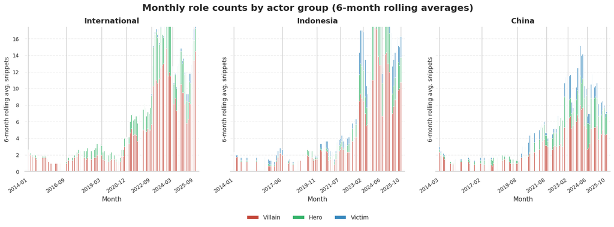

```
Rebuilt character_role_counts_over_years.png with a cleaner stacked-bar layout.
```

```python
import matplotlib.pyplot as plt
import seaborn as sns
import numpy as np

sns.set_theme(style='whitegrid')

# Rebuild the monthly role-count figure with a cleaner, publication-style layout.
fig, axes = plt.subplots(1, 3, figsize=(18, 5.4), sharey=True)
fig.patch.set_facecolor('white')

for ax, group_name in zip(axes, region_order):
    sub = count_summary[count_summary['actor_group'] == group_name].copy()
    if sub.empty:
        ax.text(0.5, 0.5, 'No data', ha='center', va='center', fontsize=12)
        ax.set_title(group_name, fontsize=13, fontweight='bold')
        ax.set_axis_off()
        continue

    sub = sub.sort_values('month').set_index('month')
    sub = sub[[*ROLE_COLS]].copy()
    sub = sub.fillna(0).astype(float)

    bottom = np.zeros(len(sub))
    for role in ROLE_COLS:
        vals = sub[role].to_numpy()
        bars = ax.bar(
            sub.index,
            vals,
            bottom=bottom,
            width=18,
            label=role.capitalize(),
            color=role_colors[role],
            edgecolor='white',
            linewidth=0.7,
            alpha=0.95,
        )
        bottom += vals

    ax.set_title(group_name, fontsize=13, fontweight='bold')
    ax.set_xlabel('Month', fontsize=11)
    ax.set_ylabel('6-month rolling avg. snippets', fontsize=10)
    ax.set_ylim(0, max(1.0, sub[[*ROLE_COLS]].sum(axis=1).max()) * 1.15)
    ax.set_axisbelow(True)
    ax.grid(axis='y', linestyle='--', alpha=0.35)
    ax.spines[['top', 'right', 'left']].set_visible(False)
    ax.tick_params(axis='both', labelsize=9)
    ax.margins(x=0.02)

    tick_idx = np.arange(0, len(sub), max(1, len(sub)//6))
    if len(tick_idx) == 0:
        tick_idx = [0]
    tick_dates = sub.index[tick_idx]
    ax.set_xticks(tick_dates)
    ax.set_xticklabels([d.strftime('%Y-%m') for d in tick_dates], rotation=35, ha='right')

handles, labels = axes[0].get_legend_handles_labels()
fig.legend(handles, labels, loc='lower center', ncol=3, frameon=False,
           bbox_to_anchor=(0.5, 0.0), fontsize=10)

fig.suptitle('Monthly role counts by actor group (6-month rolling averages)',
             fontsize=16, fontweight='bold', y=0.98)
fig.subplots_adjust(bottom=0.24, top=0.88, wspace=0.18)

plt.savefig('character_role_counts_over_years.png', dpi=300, bbox_inches='tight', facecolor='white')
plt.show()

print('Rebuilt character_role_counts_over_years.png with a cleaner stacked-bar layout.')
```

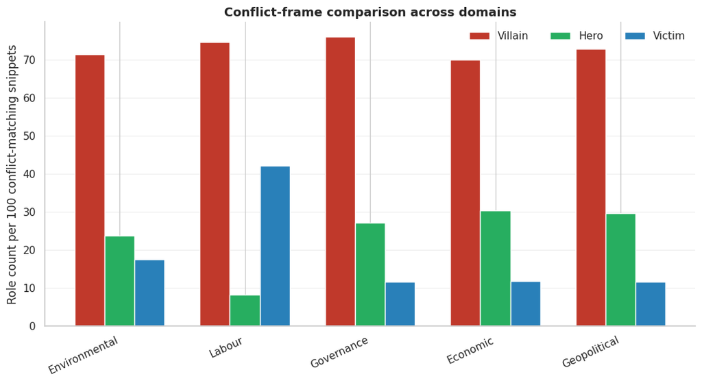

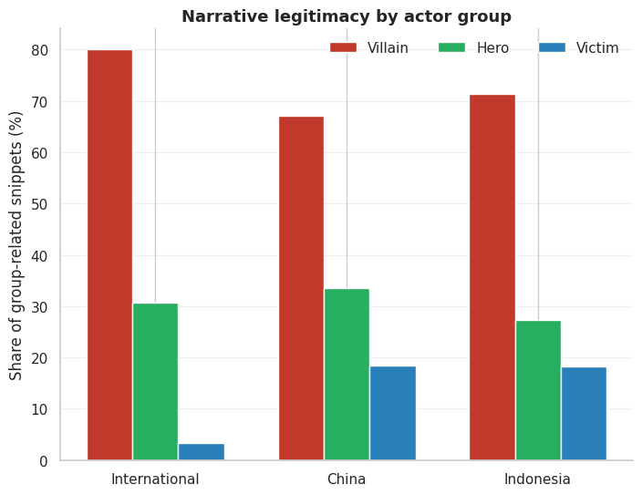

[output not shown]

```python
import textwrap
import matplotlib.pyplot as plt
import seaborn as sns
import numpy as np
import pandas as pd

# -------------------------------------------------------------------
# Additional paper figures: produce three concrete visualizations
# -------------------------------------------------------------------

paper_hook = (
    "Indonesia's nickel sector has become central to the global energy transition, "
    "given its role in electric vehicle and battery supply chains. Since the 2014 "
    "ban on raw nickel ore exports, the country has pursued a resource-nationalist "
    "strategy of downstream industrialisation that has attracted large-scale foreign "
    "investment, especially from China, while also generating contestation over "
    "environmental harm, labour conditions, governance failures, market concentration, "
    "and geopolitical tensions."
)

# 1) Conflict-frame evolution over time
# Build a simple panel of conflict-domain shares by year, using the predicted roles.
if 'pred_df' in globals() and 'date_parsed' in pred_df.columns:
    pred_df['year'] = pred_df['date_parsed'].dt.year
    conflict_domains = {
        'Environmental': ['environment', 'pollution', 'contamination', 'water', 'forest', 'health'],
        'Labour': ['labour', 'worker', 'wages', 'union', 'employment'],
        'Governance': ['governance', 'corruption', 'policy', 'regulation', 'official'],
        'Economic': ['market', 'price', 'investment', 'profit', 'finance', 'industry'],
        'Geopolitical': ['geopolitics', 'china', 'us', 'trade', 'security', 'strategic'],
    }

    domain_rows = []
    for domain, terms in conflict_domains.items():
        mask = pred_df['snippet'].str.lower().apply(lambda x: any(t in x for t in terms))
        sub = pred_df[mask].copy()
        if sub.empty:
            continue
        total = len(sub)
        for role in ROLE_COLS:
            n = int(sub[f'pred__{role}'].sum())
            domain_rows.append({'domain': domain, 'role': role, 'count': n, 'domain_total': total, 'rate_per_100': 100 * n / total})

    domain_role_summary = pd.DataFrame(domain_rows)
    if not domain_role_summary.empty:
        fig, ax = plt.subplots(figsize=(10.5, 5.8))
        fig.patch.set_facecolor('white')

        x = np.arange(len(conflict_domains))
        width = 0.24
        for i, role in enumerate(ROLE_COLS):
            vals = domain_role_summary[domain_role_summary['role'] == role].set_index('domain').reindex(list(conflict_domains.keys()))['rate_per_100'].fillna(0).values
            ax.bar(x + (i - 1) * width, vals, width=width, label=role.capitalize(), color=ROLE_COLORS[role], edgecolor='white')

        ax.set_xticks(x)
        ax.set_xticklabels(list(conflict_domains.keys()), rotation=25, ha='right')
        ax.set_ylabel('Role count per 100 conflict-matching snippets')
        ax.set_title('Conflict-frame comparison across domains', fontsize=13, fontweight='bold')
        ax.grid(axis='y', alpha=0.3)
        ax.spines[['top', 'right']].set_visible(False)
        ax.legend(frameon=False, ncol=3)
        plt.tight_layout()
        plt.savefig('figure_conflict_frame_evolution.png', dpi=300, bbox_inches='tight', facecolor='white')
        plt.show()

# 2) Narrative legitimacy triangle
# Compare the role shares across broad actor groups.
if 'pred_df' in globals():
    actor_group_map = {
        'International': ['International governmental and intergovernmental actors', 'International companies', 'International NGOs/watchdog'],
        'China': ['Chinese DFIs (banks)', 'Chinese firms/SOEs', 'Chinese government', 'Chinese worker'],
        'Indonesia': ['Indonesian government: central government/president', 'Indonesian government: local government (provincial/regional officials)', 'Indonesian firms and local elites', 'Indonesian local civil society', 'Indonesian local community & workers'],
    }

    broad_rows = []
    for group_name, labels in actor_group_map.items():
        terms = []
        for rec in codebook:
            if rec['actor_label'] in labels:
                terms.extend(_expand_codebook_terms(rec['named_entities']) + _expand_codebook_terms(rec['trigger_phrases']))
        terms = [t.lower().strip() for t in terms if t and t.strip()]
        if not terms:
            continue
        pattern = re.compile('|'.join(r'\b' + re.escape(t) + r'\b' for t in terms), re.IGNORECASE)
        group_mask = pred_df['snippet'].apply(lambda x: bool(pattern.search(str(x))))
        group_df = pred_df[group_mask].copy()
        if group_df.empty:
            continue
        total = len(group_df)
        for role in ROLE_COLS:
            n = int(group_df[f'pred__{role}'].sum())
            broad_rows.append({'actor_group': group_name, 'role': role, 'share_pct': 100 * n / total})

    broad_summary = pd.DataFrame(broad_rows).pivot(index='actor_group', columns='role', values='share_pct').reindex(index=['International', 'China', 'Indonesia'])
    if not broad_summary.empty:
        fig, ax = plt.subplots(figsize=(7.2, 5.6))
        x = np.arange(len(broad_summary.index))
        width = 0.24
        for i, role in enumerate(ROLE_COLS):
            ax.bar(x + (i - 1) * width, broad_summary[role].values, width=width, label=role.capitalize(), color=ROLE_COLORS[role], edgecolor='white')
        ax.set_xticks(x)
        ax.set_xticklabels(broad_summary.index, rotation=0)
        ax.set_ylabel('Share of group-related snippets (%)')
        ax.set_title('Narrative legitimacy by actor group', fontsize=13, fontweight='bold')
        ax.legend(frameon=False, ncol=3)
        ax.grid(axis='y', alpha=0.3)
        ax.spines[['top', 'right']].set_visible(False)
        plt.tight_layout()
        plt.savefig('figure_narrative_legitimacy_triangle.png', dpi=300, bbox_inches='tight', facecolor='white')
        plt.show()

proposal_text = f"""
Potential paper figures beyond the current role/actor summaries:

1. Conflict-frame evolution over time
   - A cross-sectional figure showing how the five conflict domains (environmental, labour, governance, economic, geopolitical) differ in their role framing once we adjust for the size of each conflict domain.
   - The plot uses role counts per 100 conflict-matching snippets, so larger conflict domains do not mechanically dominate the comparison.
   - This directly speaks to the paper's argument that the nickel story is framed differently across distinct conflict arenas.

2. Narrative legitimacy triangle
   - A figure showing the relative prominence of villain, hero, and victim frames across actor groups (Indonesia, China, International actors).
   - This visualises who is blamed, defended, or framed as suffering in the media narrative.
   - It makes the legitimacy argument more visible by showing whether blame is concentrated on state actors, firms, or foreign investors.

Framing note:
{paper_hook}
"""

print(textwrap.fill(proposal_text, width=100))

with open('character_role_figure_proposals.txt', 'w', encoding='utf-8') as fh:
    fh.write(proposal_text)

print('\nSaved: character_role_figure_proposals.txt')
```